# iLykei Lecture Series Machine Learning Support vector Machines Workshop 2: Comparing Classification Methods on Isolate Data

Y.Balasanov, L.Nazarov, © iLykei 2016-2022

**This project compares gradient boosting and SVM models on ISOLET data using package `caret`**.

# 1 Data

```r
library(caret)
library(kernlab)
library(gbm)
library(ROCR)
```

Prepare the data.

```r
dTrain = read.table(paste0(datapath,"isolet1234.data.gz"),
                    header=FALSE,sep=',',
                    stringsAsFactors=FALSE,blank.lines.skip=TRUE)
dTrain$isTest <- FALSE
dTest = read.table(paste0(datapath,"isolet5.data.gz"),
                   header=FALSE,sep=',',
                   stringsAsFactors=FALSE,blank.lines.skip=TRUE)
dTest$isTest <- TRUE
d <- rbind(dTrain,dTest)
rm(list=c('dTest','dTrain'))
d$V618 <- letters[d$V618]
vars <- colnames(d)[1:617]
yColumn <- 'isLetter'
d <- d[d$V618 %in% c('m','n'),,drop=FALSE]
trainX = d[!d$isTest,vars]
trainY = as.factor(d[!d$isTest,'V618'])
testX = d[d$isTest,vars]
testY = as.factor(d[d$isTest,'V618'])
```

Prepare training scheme for tuning parameters using 5-fold cross validation.

```r
ctrl <- trainControl(method = "cv", number = 5, classProbs =  TRUE)
```

# 2 SVM with radial kernel

SVM with radial kernel model has 2 main parameters:

- Parameter $C$ is responsible for cost of misclassification in the “soft margin” version of SVM. In other words it controls the trade-off between bias and variance. A large C gives low bias and high variance by penalizing more for misclassification. A small C allows higher bias and makes variance lower.
- Parameter $\gamma$ defines smoothness of classification rule or how far the influence of a single observation goes. Low values of $\gamma$ expands the radius of influence and small values decrease it. Parameter $\gamma$ is inverse of radius of influence $\sigma$
  $$\gamma=\frac{1}{\sigma},$$
  where $\sigma$ is a tuning parameter for radial SVM kernel in package `kernlab` used by `caret` for SVM.

Function `train()` from library `caret` searches parameters on the grid `tuneGrid`.  
Keep parameter `sigma` constant and change parameter `C` as sequence 1, 2, 4, 8, 16.  
Data are normalized before fitting.  
By default optimal classification model is selected by finding maximum of accuracy.

```r
set.seed(0)
svmFitIso <- train(trainX,trainY,
                  method = "svmRadial",
                  tuneGrid = data.frame(.C = c(1,2,4,8,16),
                                        .sigma = .001),
                  trControl = ctrl,
                  preProc = c("center", "scale"))
```

Print summary of the optimization results and plot them

```r
print(svmFitIso)
```

```
## Support Vector Machines with Radial Basis Function Kernel
##
## 480 samples
## 617 predictors
##   2 classes: 'm', 'n'
##
## Pre-processing: centered (617), scaled (617)
## Resampling: Cross-Validated (5 fold)
## Summary of sample sizes: 384, 384, 384, 384, 384
## Resampling results across tuning parameters:
##
##   C   Accuracy   Kappa
##    1  0.9354167  0.8708333
##    2  0.9395833  0.8791667
##    4  0.9395833  0.8791667
##    8  0.9375000  0.8750000
##   16  0.9291667  0.8583333
##
## Tuning parameter 'sigma' was held constant at a value of 0.001
## Accuracy was used to select the optimal model using the largest value.
## The final values used for the model were sigma = 0.001 and C = 2.
```

```r
head(with(svmFitIso, results[order(results$Kappa, decreasing=T),]))
```

```
##    C sigma  Accuracy     Kappa  AccuracySD    KappaSD
## 2  2 0.001 0.9395833 0.8791667 0.004658475 0.00931695
## 3  4 0.001 0.9395833 0.8791667 0.011410887 0.02282177
## 4  8 0.001 0.9375000 0.8750000 0.012757759 0.02551552
## 1  1 0.001 0.9354167 0.8708333 0.013581672 0.02716334
## 5 16 0.001 0.9291667 0.8583333 0.013581672 0.02716334
```

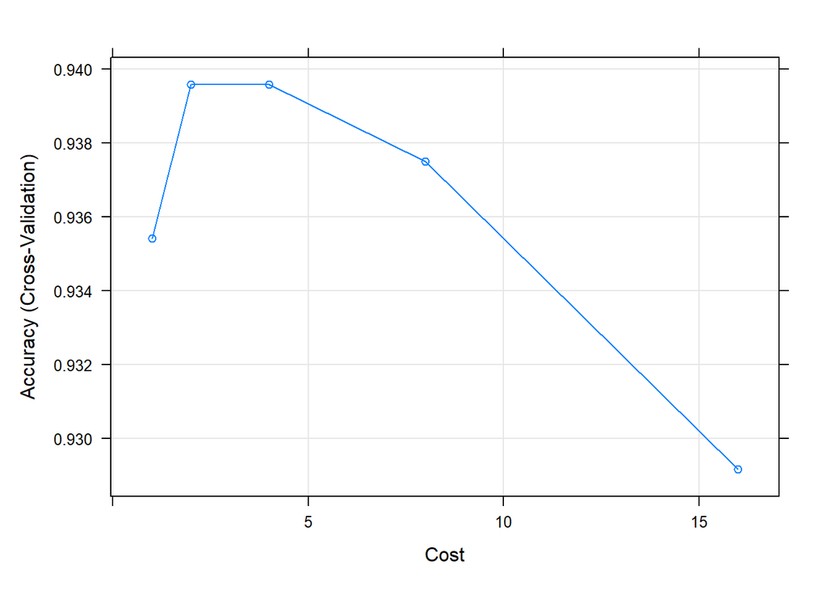

```r
plot(svmFitIso)
```

Function `predict()` gives class prediction for a new sample.

```r
svmPred = predict(svmFitIso,d[d$isTest,vars])
```

Get confusion matrix of test data

```r
table(predict(svmFitIso, d[d$isTest,vars],type='raw'), testY)
```

```
##    testY
##      m  n
##   m 53  9
##   n  6 51
```

Prediction probabilities of test data classes can be calculated as

```r
probs <- predict(svmFitIso, d[d$isTest,vars], type='prob')[,1]
head(probs)
```

```
## [1] 0.99991668 0.99804303 0.00146314 0.01536781 0.98647650 0.99347236
```

Plot the ROC curve and evaluate AUC (area under curve).

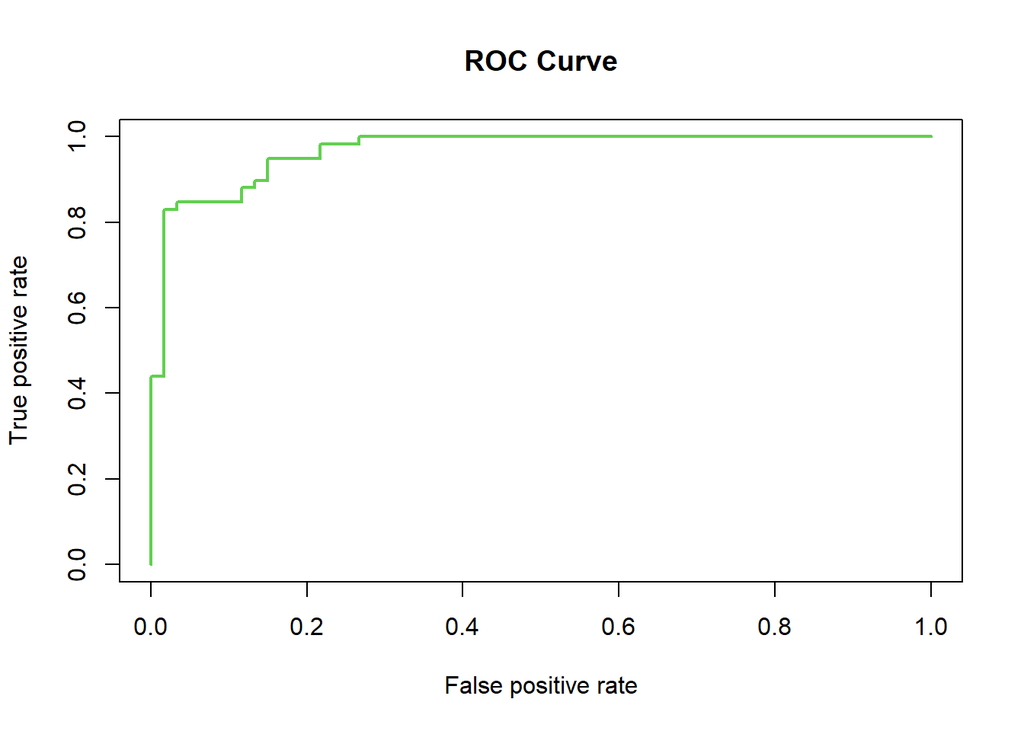

```r
isPositiveClass <- testY == 'm' # for a ROC curve there is a positive class
pred <- prediction(probs, isPositiveClass)
perf <- performance(pred, 'tpr', 'fpr')
plot(perf, lwd=2, col=3,main='ROC Curve')
```

```r
(AUC <- attributes(performance(pred, 'auc'))$y.value[[1]]) # area under curve
```

```
## [1] 0.9672316
```

# 3 Gradient boosting

Now use `caret` for tuning parameters of Gradient Boosting Machine and compare results with SVM.

```r
set.seed(0)
#n.trees, interaction.depth, shrinkage, n.minobsinnode
gbmGrid <- data.frame(n.trees = (10:12)*25, interaction.depth = 5,
                       shrinkage = .1,n.minobsinnode=2)
gbmFitIso <- train(trainX,trainY,
                   method = "gbm", tuneGrid = gbmGrid,
                   trControl = ctrl,verbose=F)
print(gbmFitIso)
```

```
## Stochastic Gradient Boosting
##
## 480 samples
## 617 predictors
##   2 classes: 'm', 'n'
##
## No pre-processing
## Resampling: Cross-Validated (5 fold)
## Summary of sample sizes: 384, 384, 384, 384, 384
## Resampling results across tuning parameters:
##
##   n.trees  Accuracy   Kappa
##   250      0.9312500  0.8625000
##   275      0.9312500  0.8625000
##   300      0.9291667  0.8583333
##
## Tuning parameter 'interaction.depth' was held constant at a value of 5
##
## Tuning parameter 'shrinkage' was held constant at a value of 0.1
##
## Tuning parameter 'n.minobsinnode' was held constant at a value of 2
## Accuracy was used to select the optimal model using the largest value.
## The final values used for the model were n.trees = 250, interaction.depth =
##  5, shrinkage = 0.1 and n.minobsinnode = 2.
```

```r
table(predict(gbmFitIso, d[d$isTest,vars],type='raw'), testY)
```

```
##    testY
##      m  n
##   m 52  5
##   n  7 55
```

# 4 Comparison

Collect resampling results for both models and visualize them.

```r
results <- resamples(list(GBM=gbmFitIso, SVM=svmFitIso))
```

Summarize the distributions

```r
summary(results)
```

```
##
## Call:
## summary.resamples(object = results)
##
## Models: GBM, SVM
## Number of resamples: 5
##
## Accuracy
##          Min.   1st Qu.    Median      Mean   3rd Qu.      Max. NA's
## GBM 0.8854167 0.9166667 0.9479167 0.9312500 0.9479167 0.9583333    0
## SVM 0.9375000 0.9375000 0.9375000 0.9395833 0.9375000 0.9479167    0
##
## Kappa
##          Min.   1st Qu.    Median      Mean   3rd Qu.      Max. NA's
## GBM 0.7708333 0.8333333 0.8958333 0.8625000 0.8958333 0.9166667    0
## SVM 0.8750000 0.8750000 0.8750000 0.8791667 0.8750000 0.8958333    0
```

The results can be visualized with either box-plots or dot plots.

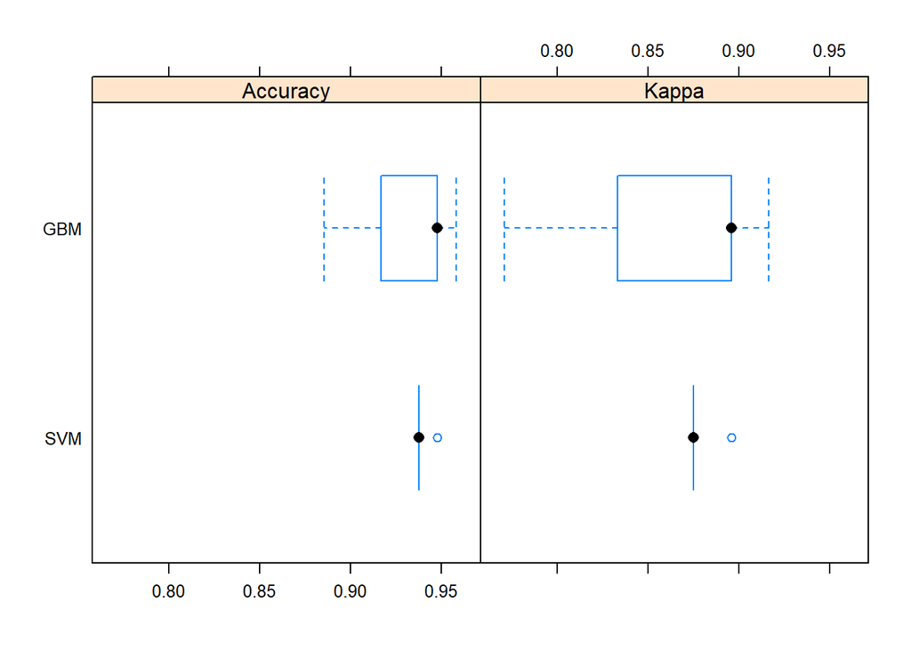

```r
bwplot(results)
```

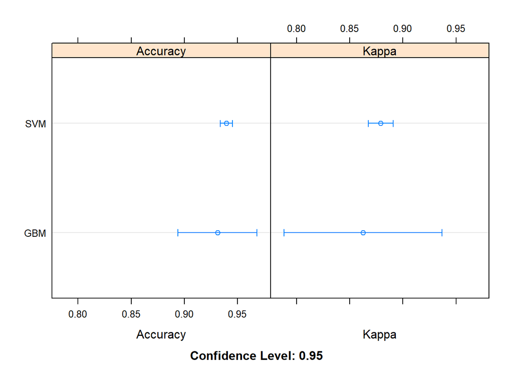

```r
dotplot(results)
```